# Geospatial Data Analysis

```r
library(sf)
my_sf = st_read("india_states_2014/india_states.shp")
```

```r
library(GADMTools)
india_wrapper = gadm_sf.loadCountries("IND", level = 1, basefile = "./")
```

```r
my_spdf = as(my_sf, "Spatial")
class(my_spdf)
```

```
[1] "SpatialPolygonsDataFrame"
attr(,"package")
[1] "sp"
```

```r
str(my_spdf, max.level = 2)
```

```
Formal class 'SpatialPolygonsDataFrame' [package "sp"] with 5 slots
  ..@ data       :'data.frame': 36 obs. of  8 variables:
  ..@ polygons   :List of 36
  ..@ plotOrder  : int [1:36] 8 30 26 35 2 29 25 1 31 18 ...
  ..@ bbox       : num [1:2, 1:2] 68.11 6.76 97.41 37.05
  .. ..- attr(*, "dimnames")=List of 2
  ..@ proj4string:Formal class 'CRS' [package "sp"] with 1 slot
```

```r
library(tidyverse)
glimpse(my_spdf@data)
```

```
Observations: 36
Variables: 8
$ id        <dbl> 28, 1, 2, 3, 5, 6, 4, 8, 12, 7, 11, 13, 17, 14, 20, 15, 16, 22, 33, 35, 34, 32, 31, 30, 29, 27...
$ name      <fct> Andhra Pradesh, Jammu & Kashmir, Himachal Pradesh, Punjab, Uttarakhand, Haryana, Chandigarh, R...
$ abbr      <fct> AP, JK, HP, PB, UT, HR, CH, RJ, AR, DL, SK, NL, ML, MN, JH, MZ, TR, CT, TN, AN, PY, KL, LD, GA...
$ geo_level <int> 3, 3, 3, 3, 3, 3, 3, 3, 3, 3, 3, 3, 3, 3, 3, 3, 3, 3, 3, 3, 3, 3, 3, 3, 3, 3, 3, 3, 3, 3, 3, 3...
$ minx      <fct> 76.7600000000000051, 72.5742599999999953, 75.6050299999999993, 73.8744200000000006, 77.5760099...
$ miny      <fct> 12.6230899999999995, 32.2647800000000018, 30.3816600000000001, 29.5142999999999986, 28.7226099...
$ maxx      <fct> 84.7149699999999939, 80.3008899999999954, 79.0511599999999959, 76.9566300000000041, 81.0374999...
$ maxy      <fct> 19.1614800000000010, 37.0503000000000000, 33.2219100000000012, 32.4924499999999981, 31.4573299...
```

```r
ind_sf = st_as_sf(my_spdf)
class(ind_sf)
```

```
[1] "sf"         "data.frame"
```

We notice that our “sp” was a SpatialPolygonDataFrame, but now we see a shift towards something consisting of two simultaneous classes: sf and data.frame. Let us print the first observations and see the difference.

```r
head(ind_sf, 4)
```

```
Simple feature collection with 4 features and 8 fields
geometry type:  MULTIPOLYGON
dimension:      XY
bbox:           xmin: 72.57426 ymin: 12.62309 xmax: 84.71497 ymax: 37.0503
epsg (SRID):    4326
proj4string:    +proj=longlat +datum=WGS84 +no_defs
  id             name abbr geo_level                minx                miny                maxx                maxy
1 28   Andhra Pradesh   AP         3 76.7600000000000051 12.6230899999999995 84.7149699999999939 19.1614800000000010
2  1  Jammu & Kashmir   JK         3 72.5742599999999953 32.2647800000000018 80.3008899999999954 37.0503000000000000
3  2 Himachal Pradesh   HP         3 75.6050299999999993 30.3816600000000001 79.0511599999999959 33.2219100000000012
4  3           Punjab   PB         3 73.8744200000000006 29.5142999999999986 76.9566300000000041 32.4924499999999981
                        geometry
1 MULTIPOLYGON (((80.0553 15....
2 MULTIPOLYGON (((77.57808 35...
3 MULTIPOLYGON (((75.80153 32...
4 MULTIPOLYGON (((75.35152 32...
```

Personally, I am more happy to analyse data in this format. The **epsg** and **proj4string** determine the co-ordinate reference system (CRS), this is a geographic CRS, giving the longitude and latitude of the states.

```r
glimpse(ind_sf)
```

```
Observations: 36
Variables: 9
$ id        <dbl> 28, 1, 2, 3, 5, 6, 4, 8, 12, 7, 11, 13, 17, 14, 20, 15, 16, 22, 33, 35, 34, 32, 31, 30, 29, 27...
$ name      <fct> Andhra Pradesh, Jammu & Kashmir, Himachal Pradesh, Punjab, Uttarakhand, Haryana, Chandigarh, R...
$ abbr      <fct> AP, JK, HP, PB, UT, HR, CH, RJ, AR, DL, SK, NL, ML, MN, JH, MZ, TR, CT, TN, AN, PY, KL, LD, GA...
$ geo_level <int> 3, 3, 3, 3, 3, 3, 3, 3, 3, 3, 3, 3, 3, 3, 3, 3, 3, 3, 3, 3, 3, 3, 3, 3, 3, 3, 3, 3, 3, 3, 3, 3...
$ minx      <fct> 76.7600000000000051, 72.5742599999999953, 75.6050299999999993, 73.8744200000000006, 77.5760099...
$ miny      <fct> 12.6230899999999995, 32.2647800000000018, 30.3816600000000001, 29.5142999999999986, 28.7226099...
$ maxx      <fct> 84.7149699999999939, 80.3008899999999954, 79.0511599999999959, 76.9566300000000041, 81.0374999...
$ maxy      <fct> 19.1614800000000010, 37.0503000000000000, 33.2219100000000012, 32.4924499999999981, 31.4573299...
$ geometry  <MULTIPOLYGON [arc_degree]> MULTIPOLYGON (((80.0553 15...., MULTIPOLYGON (((77.57808 35..., MULTIPOL...
```

Spatial dataframes in **sf** are **dataframes** and can be manipulated as such by means of packages such as **dplyr**. Let’s have a go at changing some of the column names like we would with any traditional **dataframe**. Currently the data consists of many names of “states”, but India has 29 states and 7 union territories, this in not yet evident from the above data. Let’s then manipulate the data to split the **names** into **states** and **union territories**.

```r
ind_sf$name
```

```
 [1] Andhra Pradesh            Jammu & Kashmir           Himachal Pradesh          Punjab
 [5] Uttarakhand               Haryana                   Chandigarh                Rajasthan
 [9] Arunachal Pradesh         Delhi                     Sikkim                    Nagaland
[13] Meghalaya                 Manipur                   Jharkhand                 Mizoram
[17] Tripura                   Chhattisgarh              Tamil Nadu                Andaman & Nicobar Islands
[21] Puducherry                Kerala                    Lakshadweep               Goa
[25] Karnataka                 Maharashtra               Dadra & Nagar Haveli      Daman & Diu
[29] Gujarat                   Madhya Pradesh            Odisha                    West Bengal
[33] Assam                     Bihar                     Uttar Pradesh             Telangana
36 Levels: Andaman & Nicobar Islands Andhra Pradesh Arunachal Pradesh Assam Bihar Chandigarh ... West Bengal
```

```r
length(ind_sf$name)
```

```
[1] 36
```

```r
library(dplyr)
uts = c("Delhi", "Andhra Pradesh", "Daman and Diu", "Dadra and Nagar Haveli", "Puducherry", "Andaman and Nicobar Islands", "Lakshadweep", "Chandigarh")
ind_sf <- ind_sf %>%
  select(name, abbr) %>%
  mutate(type = ifelse(name %in% uts, "Union Territory", "State")) %>%
  rename(abb = abbr, state_ut = name)
```

```r
glimpse(ind_sf)
```

[output not shown]

Note that the **geometry** variable is **sticky** and will not drop unless explicitly done so with ind_sf %>% st_set_geometry(NULL).

```r
attributes_df <- readRDS("attributes.rds")
ind_sf <- ind_sf %>%
  left_join(attributes_df, by = "state_ut") %>%
  mutate(
    per_capita_gdp_inr <- nominal_gdp_inr / pop_2011,
    per_capita_gdp_usd <- nominal_gdp_usd / pop_2011
  )
```

```
Column `state_ut` joining factor and character vector, coercing into character vector
```

The attribute data has now been joined and the addition of per capita GDP has been joined to the dataset. Let’s jump into some area calculations with the implementation of the **units** library.

```r
library(units)
library(lwgeom)
# Mutate the area
ind_sf <- ind_sf %>%
  mutate(my_area = st_area(.))
# Convert the units
units(ind_sf$my_area) <- with(ud_units, km^2)
# Mutate GDP density
ind_sf <- ind_sf %>%
  mutate(gdp_density_usd_km2 = nominal_gdp_usd / my_area)
```

We have now used units to successfully add columns utilizing units such as km^2, let’s take it a step further and start having a look at the geometry of our data.

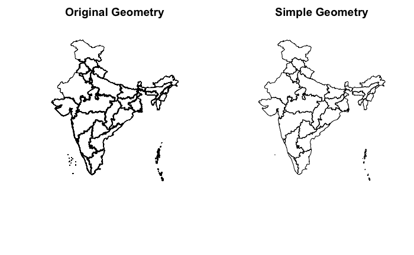

```r
ind_sf <- ind_sf %>%
  mutate(my_area = as.vector(my_area),
         gdp_density_usd_km2 = as.vector(gdp_density_usd_km2))
original_geometry <- st_geometry(ind_sf)
library(rmapshaper)
simp_sf <- ms_simplify(ind_sf, keep = 0.01, keep_shapes = TRUE)
simple_geometry <- st_geometry(simp_sf)
par(mfrow = c(1,2))
plot(original_geometry, main = "Original Geometry")
plot(simple_geometry, main = "Simple Geometry")
```

```r
library(pryr)
object.size(original_geometry)
```

```
9594424 bytes
```

```r
object.size((simple_geometry))
```

```
162496 bytes
```

```r
saveRDS(simp_sf, "simp_sf.rds")
```

# Thoughts thus far

It has been really eye-opening to see the various applications of working with geospatial data. The main take away has been the understanding of the way in which processing geospatial and attribute data is done with the help of a **tidy** work flow. The next step, static mapping, will certainly be an interesting development and I very much look forward to delving deeper into the workings behind it.

# Creating Static Maps in R

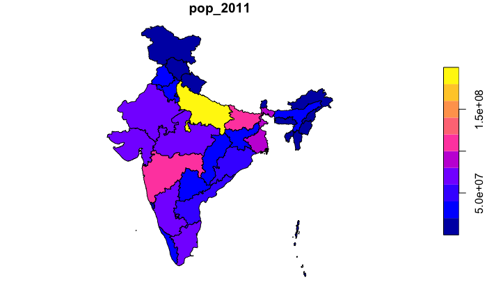

```r
library(tidyverse)
library(sf)
simp_sf <- readRDS("simp_sf.rds")
plot(simp_sf["pop_2011"])
```

## Thematic Maps (with tmaps)

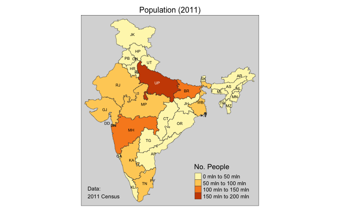

```r
library(tmap)
simp_sf %>%
  filter(!state_ut %in% c("Andaman & Nicobar Islands", "Lakshadweep"
)) %>%
  tm_shape() +
  tm_fill(col = "pop_2011", title = "No. People") +
  tm_borders(lwd = 0.5) +
  tm_text("abb", size = 0.5) +
  tm_style("gray") +
  tm_layout(
    main.title = "Population (2011)",
    main.title.position = c("center"),
    main.title.size = 1,
    legend.position = c("right", "bottom")
  ) +
  tm_credits("Data:\n2011 Census", position = c("left", "bottom"))
```

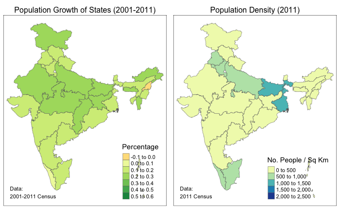

```r
library(tmap)
states_sf <- simp_sf %>%
  filter(!type == "Union Territory")
growth <- tm_shape(states_sf) +
  tm_fill(col = "decadal_growth", title = "Percentage") +
  tm_borders(lwd = 0.5) +
  tm_layout(
    main.title = "Population Growth of States (2001-2011)",
    main.title.position = c("center"),
    main.title.size = 1,
    legend.position = c("right", "bottom")
  ) +
  tm_credits("Data:\n2001-2011 Census", position = c("left", "bottom"))

density <- tm_shape(states_sf) +
  tm_fill(col = "density_km2", title = "No. People / Sq Km", palette = "YlGnBu") +
  tm_borders(lwd = 0.5) +
  tm_layout(
    main.title = "Population Density (2011)",
    main.title.position = c("center"),
    main.title.size = 1,
    legend.position = c("right", "bottom")
  ) +
  tm_credits("Data:\n2011 Census", position = c("left", "bottom"))
tmap_arrange(growth, density)
```

Another very useful aspect of tmaps is the ability to plot inset maps; plotting only part of a map and analysis data from just one part of the whole. Let’s investigate the sex ratio in Northeastern India.

```r
ne_sex <- simp_sf %>%
  filter(region == "Northeastern")
growth <- tm_shape(states_sf) +
  tm_fill(col = "sex_ratio", title = "Sex Ratio", palette = "-Reds") +
  tm_borders(lwd = 0.5) +
  tm_layout(
    main.title = "Sex Ratio (2011)",
    main.title.position = c("center"),
    main.title.size = 1
  ) +
  tm_credits("Data Source: Wikipedia", position = c("left", "top"))
regional <- simp_sf %>%
  group_by(region) %>%
  summarise(pop = sum(pop_2011))
inset <- regional %>%
  filter(!region == "Arabian Sea",
         !region == "Bay of Bengal") %>%
  mutate(northeast = ifelse(region == "Northeastern", TRUE, FALSE)) %>%
  tm_shape() +
  tm_fill(col = "northeast", palette = c("gray", "red")) +
  tm_style("cobalt") +
  tm_legend(show = FALSE)
library(grid)
ne_sex
```

```
Simple feature collection with 8 features and 19 fields
geometry type:  MULTIPOLYGON
dimension:      XY
bbox:           xmin: 88.01802 ymin: 21.9768 xmax: 97.4091 ymax: 29.48254
epsg (SRID):    4326
proj4string:    +proj=longlat +datum=WGS84 +no_defs
           state_ut abb  type      data_year comparable_economy nominal_gdp_usd nominal_gdp_inr pop_2011
1 Arunachal Pradesh  AR State 2015–16            Andorra         2.9e+09      1.9492e+11  1382611
2            Sikkim  SK State 2017–18        South Sudan         2.7e+09      1.6637e+11   607688
3          Nagaland  NL State 2014–15         East Timor         2.6e+09      1.7727e+11  1980602
4         Meghalaya  ML State 2016–17           Barbados         4.5e+09      2.9567e+11  2964007
5           Manipur  MN State 2014–15        South Sudan         2.7e+09      1.8042e+11  2721756
6           Mizoram  MZ State 2015–16         East Timor         2.5e+09      1.7561e+11  1091014
7           Tripura  TR State 2014–15           Barbados         4.5e+09      2.9666e+11  3671032
8             Assam  AS State 2018–19          Lithuania         5.1e+10      3.3300e+12 31169272
```

[output cut: 27 more lines]

```r
print(inset, vp = viewport(0.24, 0.18, width = 0.2, height = 0.4))
```

[output not shown]